# Add your Name:

# **Question 2 - Visualizations**

## **Part I**

Using the following dataset: https://raw.githubusercontent.com/mwaskom/seaborn-data/master/penguins.csv choose the most convenient graph to show the following, each question in **one** graph, using the library of your choice: (18 Marks)

**1. The relationship between the penguin's bill length and bill depth for each species.** (5 marks)

```python
## TODO: Check your attributes, make a graph using Matplotlib or Seaborn to show the relationship needed
import seaborn as sns
import matplotlib.pyplot as plt
import pandas as pd

data = pd.read_csv('C:/Users/HP/Downloads/LAB4_CSCN8000/docs/penguins.csv')
penguins = pd.DataFrame(data)

# Create a scatter plot using seaborn
sns.scatterplot(data=penguins, x='bill_length_mm', y='bill_depth_mm', hue='species', palette='viridis')

# Set plot labels and title
plt.xlabel('Bill Length (mm)')
plt.ylabel('Bill Depth (mm)')
plt.title('Relationship between Penguin\'s Bill Length and Bill Depth for Each Species')

# Show the plot
plt.show()
```

[output not shown]

[output not shown]

[output cut: 10 more lines]

[output not shown]

**What do you observe from the graph?** (2 marks)

**Why did you choose this type of graph?** (2 marks)

**2. Suitable graph of the mean BMI (BMI not body_mass weight_in_kg/height(m2)) of female and male penguins. (Assume the height is the flipper length)** (5 marks)

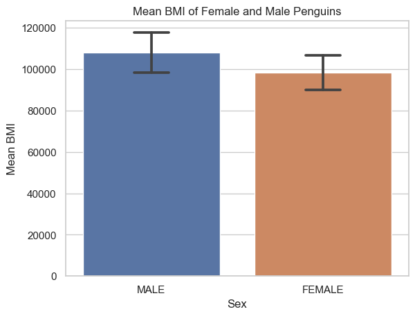

```python
#Your answer here
# Calculate BMI (Body Mass Index)
penguins['bmi'] = penguins['body_mass_g'] / ((penguins['flipper_length_mm'] / 1000) ** 2)

# Create a bar plot using seaborn
sns.barplot(x='sex', y='bmi', data=penguins, errorbar='sd', capsize=0.2)

# Set plot labels and title
plt.xlabel('Sex')
plt.ylabel('Mean BMI')
plt.title('Mean BMI of Female and Male Penguins')

# Show the plot
plt.show()
```

**What do you observe from the graph?** (2 marks)

Your answer here: BMI Comparison: The bar plot compares the mean BMI (Body Mass Index) between female and male penguins.

Sexual Dimorphism: The plot reveals whether there is a significant difference in BMI between female and male penguins. If one of the bars is noticeably higher than the other, it suggests a potential difference in body mass relative to flipper length.

Error Bars: Error bars with standard deviation provide an indication of the variability in BMI within each group.

Capsize: The capsize parameter adds horizontal lines at the end of the error bars, making it easier to interpret the level of uncertainty in the mean BMI.

**Why did you choose this type of graph?** (2 marks)

Your answer here:

- the chosen bar plot effectively communicates the mean BMI of female and male penguins, allowing for a quick comparison between the two groups and an assessment of potential differences.

## **Part II**

You can find the csv file that contains the museum visitors data here: ./CSVs/museum_visitors.csv (8 marks)

Review the data by taking a look at a few of the rows.

```python
# Your solution here
museum_data = pd.read_csv('C:/Users/HP/Downloads/LAB4_CSCN8000/docs/museum_visitors.csv')
print(museum_data.head())
```

```
         Date  Avila Adobe  Firehouse Museum  Chinese American Museum
0  2014-01-01        24778              4486                     1581  \
1  2014-02-01        18976              4172                     1785
2  2014-03-01        25231              7082                     3229
3  2014-04-01        26989              6756                     2129
4  2014-05-01        36883             10858                     3676

   America Tropical Interpretive Center
0                                  6602
1                                  5029
2                                  8129
3                                  2824
4                                 10694
```

Convince the museum board

The Firehouse Museum claims they ran an event in 2014 that brought an incredible number of visitors, and that they should get extra budget to run a similar event again. The other museums think these types of events aren't that important, and budgets should be split purely based on recent visitors on an average day.

To show the museum board how the event compared to regular traffic at each museum, create a suitable chart that shows how the number of visitors to each museum evolved over time. (4 marks)

[figure not shown]

```python
#Your solution here

# Plot the evolution of visitors for each museum
sns.lineplot(x='Date', y='Firehouse Museum', data=museum_data, label='Firehouse Museum')
sns.lineplot(x='Date', y='Chinese American Museum', data=museum_data, label='Chinese American Museum')
sns.lineplot(x='Date', y='America Tropical Interpretive Center', data=museum_data, label='America Tropical Interpretive Center')
sns.lineplot(x='Date', y='Avila Adobe', data=museum_data, label='Avila Adobe')

# Highlight the event year (2014)
plt.axvline(x=2014, color='red', linestyle='--', label='Event Year (2014)')

# Set plot labels and title
plt.xlabel('Date')
plt.ylabel('Number of Visitors')
plt.title('Evolution of Visitors to Museums Over Time')

# Show legend
plt.legend()

# Show the plot
plt.show()
```

What did you observe from the graph? (2 marks)

Why did you choose this type of graph? (2 marks)

## **PART III**

Using the file in ./CSVs/gas_prices.csv  
Use a suitable plot/graph that will show the relationship between the gas price for each country (vs others) over all years. (8 marks)

First, review the data by taking a look at a few of the rows.

```python
# Your solution here

gasprices_data = pd.read_csv('C:/Users/HP/Downloads/LAB4_CSCN8000/docs/gas_prices.csv')
print(gasprices_data.head())
```

```
   Year  Australia  Canada  France  Germany  Italy  Japan  Mexico
0  1990        NaN    1.87    3.63     2.65   4.59   3.16    1.00  \
1  1991       1.96    1.92    3.45     2.90   4.50   3.46    1.30
2  1992       1.89    1.73    3.56     3.27   4.53   3.58    1.50
3  1993       1.73    1.57    3.41     3.07   3.68   4.16    1.56
4  1994       1.84    1.45    3.59     3.52   3.70   4.36    1.48

   South Korea    UK   USA
0         2.05  2.82  1.16
1         2.49  3.01  1.14
2         2.65  3.06  1.13
3         2.88  2.84  1.11
4         2.87  2.99  1.11
```

Then Plot using the most suitable plot on your opinion (5 marks)

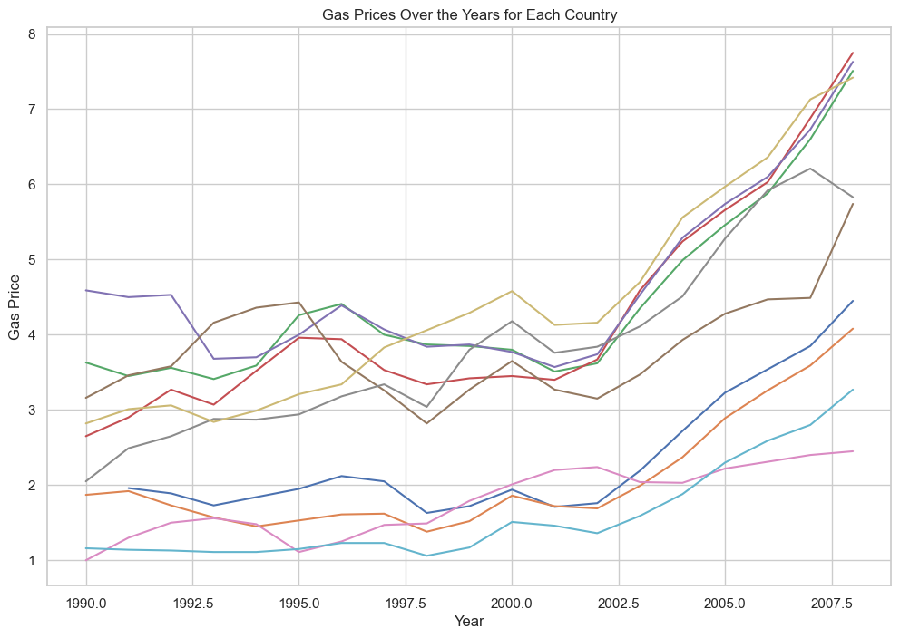

```python
## Your solution here

# Plotting the gas prices for each country over all years
plt.figure(figsize=(12, 8))
sns.lineplot(x='Year', y='Australia', data=gasprices_data)
sns.lineplot(x='Year', y='Canada', data=gasprices_data)
sns.lineplot(x='Year', y='France', data=gasprices_data)
sns.lineplot(x='Year', y='Germany', data=gasprices_data)
sns.lineplot(x='Year', y='Italy', data=gasprices_data)
sns.lineplot(x='Year', y='Japan', data=gasprices_data)
sns.lineplot(x='Year', y='Mexico', data=gasprices_data)
sns.lineplot(x='Year', y='South Korea', data=gasprices_data)
sns.lineplot(x='Year', y='UK', data=gasprices_data)
sns.lineplot(x='Year', y='USA', data=gasprices_data)
plt.title('Gas Prices Over the Years for Each Country')
plt.xlabel('Year')
plt.ylabel('Gas Price')
plt.show()
```

Is there anything interesting observed from the plot/graph? (1 mark)

Your answer here

*Trends Over Time: The plot shows the trends in gas prices over the years for each country. It allows for a visual comparison of how gas prices have changed over time in different countries.

Variability Between Countries: There are noticeable variations in the gas prices between countries. Some countries might exhibit similar trends, while others may have different patterns.

Yearly Patterns: The plot helps identify any recurring patterns or trends in gas prices over the years for each country.

Why did you c hoose this type of graph?(2 marks)

You answer here

- the chosen line plot effectively communicates the trends in gas prices over the years for each country and facilitates comparisons between countries.